# FINAL

#### Import and filtering the data

```python
import pandas as pd
#This code reads a csv file from a specified location
dfFull = pd.read_csv('eas_fall22_exam2.csv')

#This code saves the csv file as a Pandas Data Frame
dfFull
```

|  | Property1 | Property2 | Property 3 | Feature1 | Feature2 | Feature3 | Feature4 | Feature5 | Feature6 | Feature7 | ... | Feature16 | Feature17 | Feature18 | Feature19 | Feature20 | Feature21 | Feature22 | Feature23 | Feature24 | Feature25 |
| --- | --- | --- | --- | --- | --- | --- | --- | --- | --- | --- | --- | --- | --- | --- | --- | --- | --- | --- | --- | --- | --- |
| 0 | NaN | NaN | NaN | 0.0 | 10.0 | 25.0 | 0.0 | 1373.0 | 75.0 | 1173.0 | ... | 0.131 | 0.948 | 1597.254 | 15.884 | 125.28 | 0.705 | 177.65 | 45.121 | 1080.0 | 30.0 |
| 1 | NaN | NaN | NaN | 0.0 | 10.0 | 25.0 | 0.0 | 1373.0 | 75.0 | 1173.0 | ... | 0.131 | 0.948 | 1597.254 | 15.884 | 125.28 | 0.705 | 177.65 | 45.121 | 640.0 | 42.0 |
| 2 | NaN | NaN | NaN | 0.0 | 10.0 | 25.0 | 0.0 | 1373.0 | 75.0 | 1173.0 | ... | 0.131 | 0.948 | 1597.254 | 15.884 | 125.28 | 0.705 | 177.65 | 45.121 | 440.0 | 63.0 |
| 3 | NaN | NaN | NaN | 0.0 | 20.0 | 45.0 | 0.0 | 1373.0 | 75.0 | 1273.0 | ... | 0.131 | 0.948 | 1597.254 | 15.884 | 125.28 | 0.705 | 177.65 | 45.121 | 320.0 | 82.0 |
| 4 | NaN | NaN | NaN | 0.0 | 20.0 | 45.0 | 0.0 | 1373.0 | 75.0 | 1223.0 | ... | 0.131 | 0.948 | 1597.254 | 15.884 | 125.28 | 0.705 | 177.65 | 45.121 | 378.7 | 54.0 |
| ... | ... | ... | ... | ... | ... | ... | ... | ... | ... | ... | ... | ... | ... | ... | ... | ... | ... | ... | ... | ... | ... |
| 495 | NaN | NaN | NaN | NaN | NaN | NaN | NaN | NaN | NaN | NaN | ... | NaN | NaN | NaN | NaN | NaN | NaN | NaN | NaN | NaN | NaN |
| 496 | NaN | NaN | NaN | NaN | NaN | NaN | NaN | NaN | NaN | NaN | ... | NaN | NaN | NaN | NaN | NaN | NaN | NaN | NaN | NaN | NaN |
| 497 | NaN | NaN | NaN | NaN | NaN | NaN | NaN | NaN | NaN | NaN | ... | NaN | NaN | NaN | NaN | NaN | NaN | NaN | NaN | NaN | NaN |
| 498 | NaN | NaN | NaN | NaN | NaN | NaN | NaN | NaN | NaN | NaN | ... | NaN | NaN | NaN | NaN | NaN | NaN | NaN | NaN | NaN | NaN |
| 499 | NaN | NaN | NaN | NaN | NaN | NaN | NaN | NaN | NaN | NaN | ... | NaN | NaN | NaN | NaN | NaN | NaN | NaN | NaN | NaN | NaN |

500 rows × 28 columns

#### Dropping NULLs

```python
# dropping all rows containing only empty values
dfFull.dropna(how='all', inplace=True)
# creating a new dataframe
dfFull
```

|  | Property1 | Property2 | Property 3 | Feature1 | Feature2 | Feature3 | Feature4 | Feature5 | Feature6 | Feature7 | ... | Feature16 | Feature17 | Feature18 | Feature19 | Feature20 | Feature21 | Feature22 | Feature23 | Feature24 | Feature25 |
| --- | --- | --- | --- | --- | --- | --- | --- | --- | --- | --- | --- | --- | --- | --- | --- | --- | --- | --- | --- | --- | --- |
| 0 | NaN | NaN | NaN | 0.0 | 10.0 | 25.0 | 0.0 | 1373.0 | 75.0 | 1173.0 | ... | 0.131 | 0.948 | 1597.254 | 15.884 | 125.28 | 0.705 | 177.650 | 45.121 | 1080.0 | 30.0 |
| 1 | NaN | NaN | NaN | 0.0 | 10.0 | 25.0 | 0.0 | 1373.0 | 75.0 | 1173.0 | ... | 0.131 | 0.948 | 1597.254 | 15.884 | 125.28 | 0.705 | 177.650 | 45.121 | 640.0 | 42.0 |
| 2 | NaN | NaN | NaN | 0.0 | 10.0 | 25.0 | 0.0 | 1373.0 | 75.0 | 1173.0 | ... | 0.131 | 0.948 | 1597.254 | 15.884 | 125.28 | 0.705 | 177.650 | 45.121 | 440.0 | 63.0 |
| 3 | NaN | NaN | NaN | 0.0 | 20.0 | 45.0 | 0.0 | 1373.0 | 75.0 | 1273.0 | ... | 0.131 | 0.948 | 1597.254 | 15.884 | 125.28 | 0.705 | 177.650 | 45.121 | 320.0 | 82.0 |
| 4 | NaN | NaN | NaN | 0.0 | 20.0 | 45.0 | 0.0 | 1373.0 | 75.0 | 1223.0 | ... | 0.131 | 0.948 | 1597.254 | 15.884 | 125.28 | 0.705 | 177.650 | 45.121 | 378.7 | 54.0 |
| ... | ... | ... | ... | ... | ... | ... | ... | ... | ... | ... | ... | ... | ... | ... | ... | ... | ... | ... | ... | ... | ... |
| 85 | 1470.0 | 15.0 | 0.0 | 0.0 | 0.0 | 34.0 | 6.0 | 1473.0 | 70.0 | 948.0 | ... | 0.154 | 1.009 | 1590.189 | 13.684 | 98.30 | 0.360 | 97.364 | 26.129 | 366.0 | 59.0 |
| 86 | 1050.0 | 22.0 | 1.0 | 0.0 | 0.0 | 34.0 | 6.0 | 1473.0 | 70.0 | 948.0 | ... | 0.154 | 1.009 | 1590.189 | 13.684 | 98.30 | 0.360 | 97.364 | 26.129 | 261.0 | 60.4 |
| 87 | 1020.0 | 36.0 | 0.0 | 0.0 | 0.0 | 34.0 | 6.0 | 1473.0 | 70.0 | 948.0 | ... | 0.154 | 1.009 | 1590.189 | 13.684 | 98.30 | 0.360 | 97.364 | 26.129 | 210.0 | 73.1 |
| 88 | 1270.0 | 20.0 | 1.0 | 0.0 | 0.0 | 34.0 | 6.0 | 1473.0 | 70.0 | 973.0 | ... | 0.154 | 1.009 | 1590.189 | 13.684 | 98.30 | 0.360 | 97.364 | 26.129 | 1072.0 | 9.1 |
| 89 | 1100.0 | 32.0 | 0.0 | 0.0 | 0.0 | 34.0 | 6.0 | 1473.0 | 70.0 | 973.0 | ... | 0.154 | 1.009 | 1590.189 | 13.684 | 98.30 | 0.360 | 97.364 | 26.129 | 1011.0 | 10.4 |

90 rows × 28 columns

#### Preping the Data

```python
#Split the dataframe into two subsets
#Create a subset dfGuess that contains the first 10 rows of dfFull
dfGuess = dfFull[:10]

#Create a subset df that contains all rows from 10 onwards, dropping all rows with all NaN values
df = dfFull[10:].dropna(how='all')

#Display both subsets
display(dfGuess)
display(df)
```

|  | Property1 | Property2 | Property 3 | Feature1 | Feature2 | Feature3 | Feature4 | Feature5 | Feature6 | Feature7 | ... | Feature16 | Feature17 | Feature18 | Feature19 | Feature20 | Feature21 | Feature22 | Feature23 | Feature24 | Feature25 |
| --- | --- | --- | --- | --- | --- | --- | --- | --- | --- | --- | --- | --- | --- | --- | --- | --- | --- | --- | --- | --- | --- |
| 0 | NaN | NaN | NaN | 0.0 | 10.0 | 25.0 | 0.0 | 1373.0 | 75.0 | 1173.0 | ... | 0.131 | 0.948 | 1597.254 | 15.884 | 125.28 | 0.705 | 177.650 | 45.121 | 1080.0 | 30.0 |
| 1 | NaN | NaN | NaN | 0.0 | 10.0 | 25.0 | 0.0 | 1373.0 | 75.0 | 1173.0 | ... | 0.131 | 0.948 | 1597.254 | 15.884 | 125.28 | 0.705 | 177.650 | 45.121 | 640.0 | 42.0 |
| 2 | NaN | NaN | NaN | 0.0 | 10.0 | 25.0 | 0.0 | 1373.0 | 75.0 | 1173.0 | ... | 0.131 | 0.948 | 1597.254 | 15.884 | 125.28 | 0.705 | 177.650 | 45.121 | 440.0 | 63.0 |
| 3 | NaN | NaN | NaN | 0.0 | 20.0 | 45.0 | 0.0 | 1373.0 | 75.0 | 1273.0 | ... | 0.131 | 0.948 | 1597.254 | 15.884 | 125.28 | 0.705 | 177.650 | 45.121 | 320.0 | 82.0 |
| 4 | NaN | NaN | NaN | 0.0 | 20.0 | 45.0 | 0.0 | 1373.0 | 75.0 | 1223.0 | ... | 0.131 | 0.948 | 1597.254 | 15.884 | 125.28 | 0.705 | 177.650 | 45.121 | 378.7 | 54.0 |
| 5 | NaN | NaN | NaN | 0.0 | 20.0 | 45.0 | 0.0 | 1373.0 | 75.0 | 1173.0 | ... | 0.131 | 0.948 | 1597.254 | 15.884 | 125.28 | 0.705 | 177.650 | 45.121 | 520.9 | 40.0 |
| 6 | NaN | NaN | NaN | 0.0 | 20.0 | 45.0 | 0.0 | 1373.0 | 75.0 | 1073.0 | ... | 0.113 | 0.834 | 1626.428 | 15.832 | 124.65 | 0.731 | 184.025 | 54.238 | 643.8 | 32.0 |
| 7 | NaN | NaN | NaN | 0.0 | 10.0 | 25.0 | 0.0 | 1373.0 | 75.0 | 1173.0 | ... | 0.113 | 0.834 | 1626.428 | 15.832 | 124.65 | 0.731 | 184.025 | 54.238 | 272.0 | 47.0 |
| 8 | NaN | NaN | NaN | 0.0 | 10.0 | 15.0 | 0.0 | 1373.0 | 75.0 | 1173.0 | ... | 0.113 | 0.834 | 1626.428 | 15.832 | 124.65 | 0.731 | 184.025 | 54.238 | 743.0 | 49.0 |
| 9 | NaN | NaN | NaN | 0.0 | 10.0 | 5.0 | 0.0 | 1373.0 | 75.0 | 1173.0 | ... | 0.113 | 0.834 | 1626.428 | 15.832 | 124.65 | 0.731 | 184.025 | 54.238 | 733.0 | 19.0 |

10 rows × 28 columns

|  | Property1 | Property2 | Property 3 | Feature1 | Feature2 | Feature3 | Feature4 | Feature5 | Feature6 | Feature7 | ... | Feature16 | Feature17 | Feature18 | Feature19 | Feature20 | Feature21 | Feature22 | Feature23 | Feature24 | Feature25 |
| --- | --- | --- | --- | --- | --- | --- | --- | --- | --- | --- | --- | --- | --- | --- | --- | --- | --- | --- | --- | --- | --- |
| 10 | 427.0 | 70.1 | 0.0 | 0.0 | 10.0 | 0.0 | 0.0 | 1373.0 | 75.0 | 1173.0 | ... | 0.113 | 0.834 | 1626.428 | 15.832 | 124.650 | 0.731 | 184.025 | 54.238 | 807.0 | 14.0 |
| 11 | 359.0 | 55.8 | 0.0 | 0.0 | 10.0 | 5.0 | 0.0 | 1373.0 | 75.0 | 1273.0 | ... | 0.113 | 0.834 | 1626.428 | 15.832 | 124.650 | 0.731 | 184.025 | 54.238 | 939.0 | 14.0 |
| 12 | 345.0 | 57.2 | 0.0 | 0.0 | 10.0 | 2.5 | 0.0 | 1373.0 | 75.0 | 1273.0 | ... | 0.110 | 0.847 | 1705.102 | 14.462 | 142.523 | 0.819 | 202.410 | 45.923 | 401.0 | 48.0 |
| 13 | 374.0 | 66.5 | 1.0 | 0.0 | 10.0 | 0.0 | 0.0 | 1373.0 | 75.0 | 1273.0 | ... | 0.110 | 0.847 | 1705.102 | 14.462 | 142.523 | 0.819 | 202.410 | 45.923 | 740.0 | 43.9 |
| 14 | 294.0 | 36.0 | 0.0 | 0.0 | 10.0 | 15.0 | 0.0 | 1373.0 | 75.0 | 1173.0 | ... | 0.110 | 0.847 | 1705.102 | 14.462 | 142.523 | 0.819 | 202.410 | 45.923 | 390.0 | 57.0 |
| ... | ... | ... | ... | ... | ... | ... | ... | ... | ... | ... | ... | ... | ... | ... | ... | ... | ... | ... | ... | ... | ... |
| 85 | 1470.0 | 15.0 | 0.0 | 0.0 | 0.0 | 34.0 | 6.0 | 1473.0 | 70.0 | 948.0 | ... | 0.154 | 1.009 | 1590.189 | 13.684 | 98.300 | 0.360 | 97.364 | 26.129 | 366.0 | 59.0 |
| 86 | 1050.0 | 22.0 | 1.0 | 0.0 | 0.0 | 34.0 | 6.0 | 1473.0 | 70.0 | 948.0 | ... | 0.154 | 1.009 | 1590.189 | 13.684 | 98.300 | 0.360 | 97.364 | 26.129 | 261.0 | 60.4 |
| 87 | 1020.0 | 36.0 | 0.0 | 0.0 | 0.0 | 34.0 | 6.0 | 1473.0 | 70.0 | 948.0 | ... | 0.154 | 1.009 | 1590.189 | 13.684 | 98.300 | 0.360 | 97.364 | 26.129 | 210.0 | 73.1 |
| 88 | 1270.0 | 20.0 | 1.0 | 0.0 | 0.0 | 34.0 | 6.0 | 1473.0 | 70.0 | 973.0 | ... | 0.154 | 1.009 | 1590.189 | 13.684 | 98.300 | 0.360 | 97.364 | 26.129 | 1072.0 | 9.1 |
| 89 | 1100.0 | 32.0 | 0.0 | 0.0 | 0.0 | 34.0 | 6.0 | 1473.0 | 70.0 | 973.0 | ... | 0.154 | 1.009 | 1590.189 | 13.684 | 98.300 | 0.360 | 97.364 | 26.129 | 1011.0 | 10.4 |

80 rows × 28 columns

#### Delete overfitting columns

```python
#dropping two columns based on their names
df = df.drop(['Feature4','Feature2'], axis=1)
#axis=1 indicates the direction of drop is row,
#and the labels of the columns to be dropped areFeature4 and Feature2
df
```

|  | Property1 | Property2 | Property 3 | Feature1 | Feature3 | Feature5 | Feature6 | Feature7 | Feature8 | Feature9 | ... | Feature16 | Feature17 | Feature18 | Feature19 | Feature20 | Feature21 | Feature22 | Feature23 | Feature24 | Feature25 |
| --- | --- | --- | --- | --- | --- | --- | --- | --- | --- | --- | --- | --- | --- | --- | --- | --- | --- | --- | --- | --- | --- |
| 10 | 427.0 | 70.1 | 0.0 | 0.0 | 0.0 | 1373.0 | 75.0 | 1173.0 | 605.0 | 2.112 | ... | 0.113 | 0.834 | 1626.428 | 15.832 | 124.650 | 0.731 | 184.025 | 54.238 | 807.0 | 14.0 |
| 11 | 359.0 | 55.8 | 0.0 | 0.0 | 5.0 | 1373.0 | 75.0 | 1273.0 | 130.0 | 2.112 | ... | 0.113 | 0.834 | 1626.428 | 15.832 | 124.650 | 0.731 | 184.025 | 54.238 | 939.0 | 14.0 |
| 12 | 345.0 | 57.2 | 0.0 | 0.0 | 2.5 | 1373.0 | 75.0 | 1273.0 | 990.0 | 2.160 | ... | 0.110 | 0.847 | 1705.102 | 14.462 | 142.523 | 0.819 | 202.410 | 45.923 | 401.0 | 48.0 |
| 13 | 374.0 | 66.5 | 1.0 | 0.0 | 0.0 | 1373.0 | 75.0 | 1273.0 | 950.0 | 2.160 | ... | 0.110 | 0.847 | 1705.102 | 14.462 | 142.523 | 0.819 | 202.410 | 45.923 | 740.0 | 43.9 |
| 14 | 294.0 | 36.0 | 0.0 | 0.0 | 15.0 | 1373.0 | 75.0 | 1173.0 | 645.0 | 2.160 | ... | 0.110 | 0.847 | 1705.102 | 14.462 | 142.523 | 0.819 | 202.410 | 45.923 | 390.0 | 57.0 |
| ... | ... | ... | ... | ... | ... | ... | ... | ... | ... | ... | ... | ... | ... | ... | ... | ... | ... | ... | ... | ... | ... |
| 85 | 1470.0 | 15.0 | 0.0 | 0.0 | 34.0 | 1473.0 | 70.0 | 948.0 | 960.0 | 2.237 | ... | 0.154 | 1.009 | 1590.189 | 13.684 | 98.300 | 0.360 | 97.364 | 26.129 | 366.0 | 59.0 |
| 86 | 1050.0 | 22.0 | 1.0 | 0.0 | 34.0 | 1473.0 | 70.0 | 948.0 | 885.0 | 2.237 | ... | 0.154 | 1.009 | 1590.189 | 13.684 | 98.300 | 0.360 | 97.364 | 26.129 | 261.0 | 60.4 |
| 87 | 1020.0 | 36.0 | 0.0 | 0.0 | 34.0 | 1473.0 | 70.0 | 948.0 | 860.0 | 2.237 | ... | 0.154 | 1.009 | 1590.189 | 13.684 | 98.300 | 0.360 | 97.364 | 26.129 | 210.0 | 73.1 |
| 88 | 1270.0 | 20.0 | 1.0 | 0.0 | 34.0 | 1473.0 | 70.0 | 973.0 | 775.0 | 2.237 | ... | 0.154 | 1.009 | 1590.189 | 13.684 | 98.300 | 0.360 | 97.364 | 26.129 | 1072.0 | 9.1 |
| 89 | 1100.0 | 32.0 | 0.0 | 0.0 | 34.0 | 1473.0 | 70.0 | 973.0 | 755.0 | 2.237 | ... | 0.154 | 1.009 | 1590.189 | 13.684 | 98.300 | 0.360 | 97.364 | 26.129 | 1011.0 | 10.4 |

80 rows × 26 columns

```python
#This code will identify the categorical and numerical columns in the dataset

#Create objects that store the categorical and numerical columns
catCols = df.select_dtypes(include='object').columns
numCols = df.select_dtypes(include='number').columns

#Print the categorical and numerical columns
print("Categorical Columns: ", catCols)
print("Numerical Columns: ", numCols)
```

```
Categorical Columns:  Index([], dtype='object')
Numerical Columns:  Index(['Property1', 'Property2', 'Property 3', 'Feature1', 'Feature3',
       'Feature5', 'Feature6', 'Feature7', 'Feature8', 'Feature9', 'Feature10',
       'Feature11', 'Feature12', 'Feature13', 'Feature14', 'Feature15',
       'Feature16', 'Feature17', 'Feature18', 'Feature19', 'Feature20',
       'Feature21', 'Feature22', 'Feature23', 'Feature24', 'Feature25'],
      dtype='object')
```

```python
figSize = (20, 50)
```

#### For EDA:

The main purpose of doing Exploratory Data Analysis (EDA) is to explore the data, identify patterns, and gain insights that can be used to inform the design of future studies. To accomplish this, we use several methods. Visualization is used to quickly explore data distributions and identify outliers, trends, and relationships between variables. Summary statistics can provide us with an overall picture of the data, such as the mean, median, and standard deviation. Correlation analysis can tell us how two variables are related. Boxplots can be used to identify outliers and identify the range of values for each of our variables. All of these methods help us gain valuable insights about our data that can be used to inform our decisions and models.

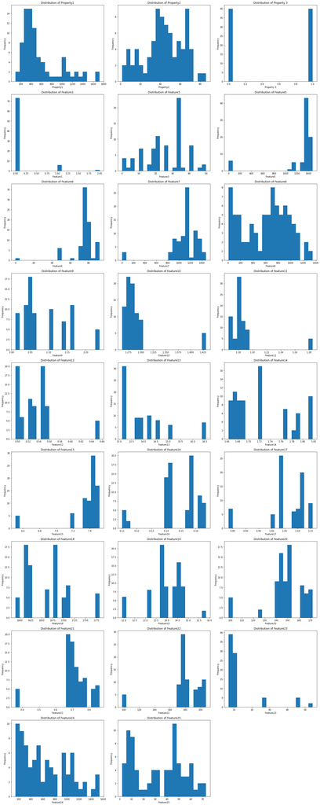

```python
#Importing the necessary libraries
import pandas as pd
import numpy as np
import matplotlib.pyplot as plt

#store numerical columns to num_cols
num_cols = df.select_dtypes(include=np.number).columns

#create new figure
plt.figure(figsize=figSize)

#iterate through columns in num_cols
for i, col in enumerate(num_cols):

#plot the histogram of the column
    plt.subplot(len(num_cols)//3 + 1, 3, i+1)
    df[col].plot.hist(bins=20, figsize=figSize)
    plt.xlabel(col)
    plt.ylabel("Frequency")
    plt.title("Distribution of "+ col)

#tighten up the layout
plt.tight_layout()

#display the plot
plt.show()
```

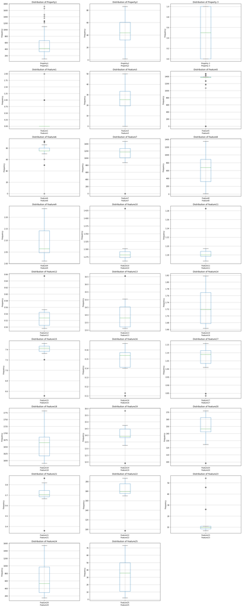

```python
#plotting all numerical columns of df in single figure
num_cols = df.select_dtypes(include=np.number).columns # creating list of all numerical columns
plt.figure(figsize=figSize) # setting figure size
for i, col in enumerate(num_cols): # using loop to plot individual columns
    plt.subplot(len(num_cols)//3 + 1, 3, i+1) # adjusting subplots
    df.boxplot(column=col,figsize=figSize)
    plt.xlabel(col) # adding x-label as name of column
    plt.ylabel("Frequency") # adding y-label
    plt.title("Distribution of "+ col) # adding title
plt.tight_layout() # tightening the layout
plt.show() # displaying the figure
```

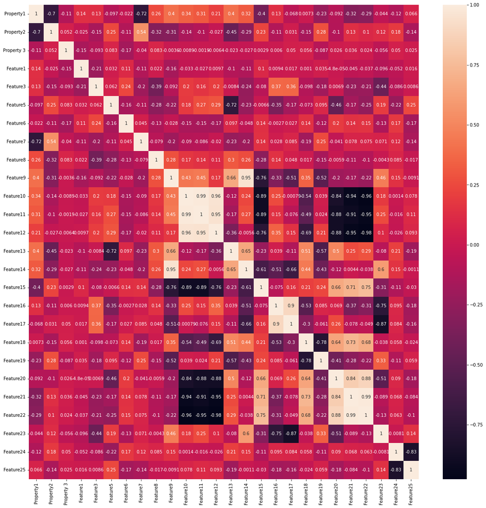

```python
# import seaborn library
import seaborn as sns

# Calculate correlation of columns in dataframe
corr = df.corr()

# Set figure size
plt.figure(figsize=(20,20))

# Generate a heatmap of correlation matrix
sns.heatmap(corr, annot=True)
```

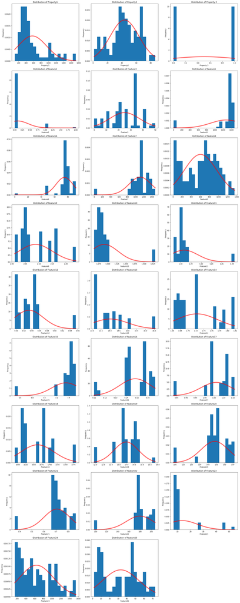

```python
import scipy

# get the numerical columns of the dataframe
num_cols = df.select_dtypes(include=np.number).columns

# set up the figure area with the appropriate size
plt.figure(figsize=figSize)

# loop through all the numerical columns
for i, col in enumerate(num_cols):

    # set up the subplot area
    plt.subplot(len(num_cols)//3 + 1, 3, i+1)

    # plot a histogram of the data
    df[col].plot.hist(density=True, bins=20, figsize=figSize)

    # create variables for the bell curve line
    x = np.linspace(df[col].min(), df[col].max(), 1000)
    y = scipy.stats.norm.pdf(x, df[col].describe().T['mean'], df[col].describe().T['std'])

    # plot the bell curve line
    plt.plot(x, y, 'r-', lw=5, alpha=0.6, label="Bell Curve")

    # add xlabel, ylabel and title
    plt.xlabel(col)
    plt.ylabel("Frequency")
    plt.title("Distribution of "+ col)

# set the layout to be tight
plt.tight_layout()

# show the figure
plt.show()
```

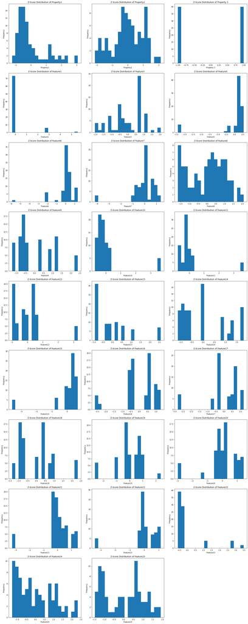

```python
# Get numeric columns
num_cols = df.select_dtypes(include=np.number).columns

# Create an empty dictionary
z_scores = {}

# Loop through numeric columns and create z-score columns
for col in num_cols:
    # Get mean and std
    mean = df[col].describe().T['mean']
    std = df[col].describe().T['std']
    # Calculate z-score
    z_scores[col] = (df[col] - mean) / std

# convert the dictionary to dataframe
z_scores = pd.DataFrame(z_scores)

# Plot the histograms
plt.figure(figsize=figSize)
for i, col in enumerate(num_cols):
    plt.subplot(len(num_cols)//3 + 1, 3, i+1)
    z_scores[col].plot.hist(bins=20, figsize=figSize)
    plt.xlabel(col)
    plt.ylabel("Frequency")
    plt.title("Z-Score Distribution of "+ col)
plt.tight_layout()
plt.show()
```

#### Data Cleaning- we use Z-scores to remove true outliers:

Using Z-scores are helpful for identifying true outliers because they provide a standardized approach for measuring and comparing the degree of dispersion in a dataset. By using z-scores, you can easily identify data points that are too far away from the mean and are therefore likely to be true outliers. This is especially useful in datasets that have multiple dimensions, as z-scores make it easy to compare data points across each dimension. Furthermore, z-scores provide a quantitative method for detecting outliers and make it easier to decide which data points should be removed from a dataset.

```python
#Calculate z-score
threshold = 3
z_score = (df - df.mean()) / df.std()

#Identify outliers
outliers = df[(abs(z_score) > threshold).any(axis=1)]

#Remove outliers
df = df[~(abs(z_score) > threshold).any(axis=1)]
```

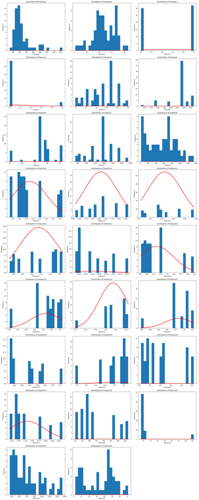

```python
# Here, we use np.number to select numerical columns from the dataframe.
num_cols = df.select_dtypes(include=np.number).columns

# Create a figure object of a particular dimension
plt.figure(figsize=figSize)

# Iterate over the numerical columns to plot the histogram
for i, col in enumerate(num_cols):
    plt.subplot(len(num_cols)//3 + 1, 3, i+1)  # Plot the graph with mentioned parameters
    df[col].plot.hist(bins=20, figsize=figSize)  # Plot graph
    x = np.linspace(df[col].min(), df[col].max(), 1000) # Generate linearly varying values
    y = scipy.stats.norm.pdf(x, df[col].describe().T['mean'], df[col].describe().T['std']) # Probability distribution
    plt.plot(x, y, 'r-', lw=5, alpha=0.6, label="Bell Curve") # Plot the probability distribution
    plt.xlabel(col) # Set X-axis label
    plt.ylabel("Frequency") # Set Y-axis Label
    plt.title("Distribution of "+ col) # Set title
plt.tight_layout() # Make sure the labels and title of plots display properly
plt.show() # Display the plots in the figure object
```

```python
targets = {}
```

#### Data Augmentation:

```python
# iterating through the columns of the dataframe
for i in range(1,4):
    print('\n')
    print("=============================================================================================")
    # display name of the particular column
    print(f'Property {i}')
    # get the correspinding y value of the column
    y = df.iloc[:, i]
    # drop the current column
    try:
        X = df.drop(f'Property {i}', axis=1)
        # store the X and y values in the dictionary
        targets[f'Property {i}'] = (X,y)
    except:
        X = df.drop(f'Property{i}', axis=1)
        targets[f'Property{i}'] = (X,y)

    # display the new X values
    display(X)
    # display the corresponding y value
    display(y)
    print('\n')
```

```
=============================================================================================
Property 1
```

|  | Property2 | Property 3 | Feature1 | Feature3 | Feature5 | Feature6 | Feature7 | Feature8 | Feature9 | Feature10 | ... | Feature16 | Feature17 | Feature18 | Feature19 | Feature20 | Feature21 | Feature22 | Feature23 | Feature24 | Feature25 |
| --- | --- | --- | --- | --- | --- | --- | --- | --- | --- | --- | --- | --- | --- | --- | --- | --- | --- | --- | --- | --- | --- |
| 12 | 57.2 | 0.0 | 0.0 | 2.5000 | 1373.0 | 75.0 | 1273.0 | 990.0 | 2.160 | 1.262 | ... | 0.110 | 0.847 | 1705.102 | 14.462 | 142.523 | 0.819 | 202.410 | 45.923 | 401.0 | 48.0 |
| 13 | 66.5 | 1.0 | 0.0 | 0.0000 | 1373.0 | 75.0 | 1273.0 | 950.0 | 2.160 | 1.262 | ... | 0.110 | 0.847 | 1705.102 | 14.462 | 142.523 | 0.819 | 202.410 | 45.923 | 740.0 | 43.9 |
| 14 | 36.0 | 0.0 | 0.0 | 15.0000 | 1373.0 | 75.0 | 1173.0 | 645.0 | 2.160 | 1.262 | ... | 0.110 | 0.847 | 1705.102 | 14.462 | 142.523 | 0.819 | 202.410 | 45.923 | 390.0 | 57.0 |
| 15 | 60.2 | 1.0 | 0.0 | 5.0000 | 1373.0 | 75.0 | 1223.0 | 360.0 | 2.160 | 1.262 | ... | 0.110 | 0.847 | 1705.102 | 14.462 | 142.523 | 0.819 | 202.410 | 45.923 | 530.0 | 60.0 |
| 16 | 40.0 | 1.0 | 0.0 | 5.0000 | 1473.0 | 50.0 | 1123.0 | 125.0 | 2.160 | 1.262 | ... | 0.110 | 0.847 | 1705.102 | 14.462 | 142.523 | 0.819 | 202.410 | 45.923 | 615.8 | 52.8 |
| ... | ... | ... | ... | ... | ... | ... | ... | ... | ... | ... | ... | ... | ... | ... | ... | ... | ... | ... | ... | ... | ... |
| 73 | 43.0 | 1.0 | 0.0 | 33.3333 | 1373.0 | 78.0 | 923.0 | 345.0 | 2.104 | 1.267 | ... | 0.141 | 1.034 | 1713.260 | 13.246 | 162.358 | 0.783 | 197.593 | 8.510 | 146.0 | 40.0 |
| 74 | 51.0 | 1.0 | 0.0 | 33.3333 | 1373.0 | 78.0 | 973.0 | 195.0 | 2.104 | 1.267 | ... | 0.141 | 1.034 | 1713.260 | 13.246 | 162.358 | 0.783 | 197.593 | 8.510 | 238.0 | 56.5 |
| 75 | 64.0 | 0.0 | 0.0 | 33.3333 | 1373.0 | 78.0 | 1073.0 | 105.0 | 2.104 | 1.267 | ... | 0.141 | 1.034 | 1713.260 | 13.246 | 162.358 | 0.783 | 197.593 | 8.510 | 530.0 | 60.2 |
| 76 | 68.0 | 0.0 | 0.0 | 33.3333 | 1373.0 | 78.0 | 1173.0 | 80.0 | 2.104 | 1.267 | ... | 0.141 | 1.034 | 1713.260 | 13.246 | 162.358 | 0.783 | 197.593 | 8.510 | 342.0 | 10.9 |
| 77 | 68.0 | 0.0 | 0.0 | 33.3333 | 1373.0 | 78.0 | 1373.0 | 50.0 | 2.104 | 1.267 | ... | 0.141 | 1.034 | 1713.260 | 13.246 | 162.358 | 0.783 | 197.593 | 8.510 | 634.0 | 7.6 |

62 rows × 25 columns

```
12    57.2
13    66.5
14    36.0
15    60.2
16    40.0
      ...
73    43.0
74    51.0
75    64.0
76    68.0
77    68.0
Name: Property2, Length: 62, dtype: float64
```

```
=============================================================================================
Property 2
```

|  | Property1 | Property 3 | Feature1 | Feature3 | Feature5 | Feature6 | Feature7 | Feature8 | Feature9 | Feature10 | ... | Feature16 | Feature17 | Feature18 | Feature19 | Feature20 | Feature21 | Feature22 | Feature23 | Feature24 | Feature25 |
| --- | --- | --- | --- | --- | --- | --- | --- | --- | --- | --- | --- | --- | --- | --- | --- | --- | --- | --- | --- | --- | --- |
| 12 | 345.0 | 0.0 | 0.0 | 2.5000 | 1373.0 | 75.0 | 1273.0 | 990.0 | 2.160 | 1.262 | ... | 0.110 | 0.847 | 1705.102 | 14.462 | 142.523 | 0.819 | 202.410 | 45.923 | 401.0 | 48.0 |
| 13 | 374.0 | 1.0 | 0.0 | 0.0000 | 1373.0 | 75.0 | 1273.0 | 950.0 | 2.160 | 1.262 | ... | 0.110 | 0.847 | 1705.102 | 14.462 | 142.523 | 0.819 | 202.410 | 45.923 | 740.0 | 43.9 |
| 14 | 294.0 | 0.0 | 0.0 | 15.0000 | 1373.0 | 75.0 | 1173.0 | 645.0 | 2.160 | 1.262 | ... | 0.110 | 0.847 | 1705.102 | 14.462 | 142.523 | 0.819 | 202.410 | 45.923 | 390.0 | 57.0 |
| 15 | 257.0 | 1.0 | 0.0 | 5.0000 | 1373.0 | 75.0 | 1223.0 | 360.0 | 2.160 | 1.262 | ... | 0.110 | 0.847 | 1705.102 | 14.462 | 142.523 | 0.819 | 202.410 | 45.923 | 530.0 | 60.0 |
| 16 | 397.0 | 1.0 | 0.0 | 5.0000 | 1473.0 | 50.0 | 1123.0 | 125.0 | 2.160 | 1.262 | ... | 0.110 | 0.847 | 1705.102 | 14.462 | 142.523 | 0.819 | 202.410 | 45.923 | 615.8 | 52.8 |
| ... | ... | ... | ... | ... | ... | ... | ... | ... | ... | ... | ... | ... | ... | ... | ... | ... | ... | ... | ... | ... | ... |
| 73 | 982.0 | 1.0 | 0.0 | 33.3333 | 1373.0 | 78.0 | 923.0 | 345.0 | 2.104 | 1.267 | ... | 0.141 | 1.034 | 1713.260 | 13.246 | 162.358 | 0.783 | 197.593 | 8.510 | 146.0 | 40.0 |
| 74 | 847.0 | 1.0 | 0.0 | 33.3333 | 1373.0 | 78.0 | 973.0 | 195.0 | 2.104 | 1.267 | ... | 0.141 | 1.034 | 1713.260 | 13.246 | 162.358 | 0.783 | 197.593 | 8.510 | 238.0 | 56.5 |
| 75 | 601.0 | 0.0 | 0.0 | 33.3333 | 1373.0 | 78.0 | 1073.0 | 105.0 | 2.104 | 1.267 | ... | 0.141 | 1.034 | 1713.260 | 13.246 | 162.358 | 0.783 | 197.593 | 8.510 | 530.0 | 60.2 |
| 76 | 474.0 | 0.0 | 0.0 | 33.3333 | 1373.0 | 78.0 | 1173.0 | 80.0 | 2.104 | 1.267 | ... | 0.141 | 1.034 | 1713.260 | 13.246 | 162.358 | 0.783 | 197.593 | 8.510 | 342.0 | 10.9 |
| 77 | 375.0 | 0.0 | 0.0 | 33.3333 | 1373.0 | 78.0 | 1373.0 | 50.0 | 2.104 | 1.267 | ... | 0.141 | 1.034 | 1713.260 | 13.246 | 162.358 | 0.783 | 197.593 | 8.510 | 634.0 | 7.6 |

62 rows × 25 columns

```
12    0.0
13    1.0
14    0.0
15    1.0
16    1.0
     ...
73    1.0
74    1.0
75    0.0
76    0.0
77    0.0
Name: Property 3, Length: 62, dtype: float64
```

```
=============================================================================================
Property 3
```

|  | Property1 | Property2 | Feature1 | Feature3 | Feature5 | Feature6 | Feature7 | Feature8 | Feature9 | Feature10 | ... | Feature16 | Feature17 | Feature18 | Feature19 | Feature20 | Feature21 | Feature22 | Feature23 | Feature24 | Feature25 |
| --- | --- | --- | --- | --- | --- | --- | --- | --- | --- | --- | --- | --- | --- | --- | --- | --- | --- | --- | --- | --- | --- |
| 12 | 345.0 | 57.2 | 0.0 | 2.5000 | 1373.0 | 75.0 | 1273.0 | 990.0 | 2.160 | 1.262 | ... | 0.110 | 0.847 | 1705.102 | 14.462 | 142.523 | 0.819 | 202.410 | 45.923 | 401.0 | 48.0 |
| 13 | 374.0 | 66.5 | 0.0 | 0.0000 | 1373.0 | 75.0 | 1273.0 | 950.0 | 2.160 | 1.262 | ... | 0.110 | 0.847 | 1705.102 | 14.462 | 142.523 | 0.819 | 202.410 | 45.923 | 740.0 | 43.9 |
| 14 | 294.0 | 36.0 | 0.0 | 15.0000 | 1373.0 | 75.0 | 1173.0 | 645.0 | 2.160 | 1.262 | ... | 0.110 | 0.847 | 1705.102 | 14.462 | 142.523 | 0.819 | 202.410 | 45.923 | 390.0 | 57.0 |
| 15 | 257.0 | 60.2 | 0.0 | 5.0000 | 1373.0 | 75.0 | 1223.0 | 360.0 | 2.160 | 1.262 | ... | 0.110 | 0.847 | 1705.102 | 14.462 | 142.523 | 0.819 | 202.410 | 45.923 | 530.0 | 60.0 |
| 16 | 397.0 | 40.0 | 0.0 | 5.0000 | 1473.0 | 50.0 | 1123.0 | 125.0 | 2.160 | 1.262 | ... | 0.110 | 0.847 | 1705.102 | 14.462 | 142.523 | 0.819 | 202.410 | 45.923 | 615.8 | 52.8 |
| ... | ... | ... | ... | ... | ... | ... | ... | ... | ... | ... | ... | ... | ... | ... | ... | ... | ... | ... | ... | ... | ... |
| 73 | 982.0 | 43.0 | 0.0 | 33.3333 | 1373.0 | 78.0 | 923.0 | 345.0 | 2.104 | 1.267 | ... | 0.141 | 1.034 | 1713.260 | 13.246 | 162.358 | 0.783 | 197.593 | 8.510 | 146.0 | 40.0 |
| 74 | 847.0 | 51.0 | 0.0 | 33.3333 | 1373.0 | 78.0 | 973.0 | 195.0 | 2.104 | 1.267 | ... | 0.141 | 1.034 | 1713.260 | 13.246 | 162.358 | 0.783 | 197.593 | 8.510 | 238.0 | 56.5 |
| 75 | 601.0 | 64.0 | 0.0 | 33.3333 | 1373.0 | 78.0 | 1073.0 | 105.0 | 2.104 | 1.267 | ... | 0.141 | 1.034 | 1713.260 | 13.246 | 162.358 | 0.783 | 197.593 | 8.510 | 530.0 | 60.2 |
| 76 | 474.0 | 68.0 | 0.0 | 33.3333 | 1373.0 | 78.0 | 1173.0 | 80.0 | 2.104 | 1.267 | ... | 0.141 | 1.034 | 1713.260 | 13.246 | 162.358 | 0.783 | 197.593 | 8.510 | 342.0 | 10.9 |
| 77 | 375.0 | 68.0 | 0.0 | 33.3333 | 1373.0 | 78.0 | 1373.0 | 50.0 | 2.104 | 1.267 | ... | 0.141 | 1.034 | 1713.260 | 13.246 | 162.358 | 0.783 | 197.593 | 8.510 | 634.0 | 7.6 |

62 rows × 25 columns

```
12    0.0
13    0.0
14    0.0
15    0.0
16    0.0
     ...
73    0.0
74    0.0
75    0.0
76    0.0
77    0.0
Name: Feature1, Length: 62, dtype: float64
```

#### For Feature Selection:

The code below is a feature selection code using various methods for 3 different dataframes each containing a property. It first uses the correlation matrix to select highly correlated features with the output variable. Then, Chi-square tests are used to calculate the significance of the selected features and the p-values are used to determine which features are more relevant. After that, Ridge and Lasso regression are used to calculate the optimal alpha and the features associated with the alpha values are selected. Finally, the selected features are printed in order to compare the different methods.

```
Target Name: Property1
Feature Selected by Corr: ['Property2', 'Feature1', 'Feature7', 'Feature10', 'Feature11']
Features Selected by Chi: The chi-squared test takes categorical label data as input.
Optimal alpha for RIDGE : 0.1
```

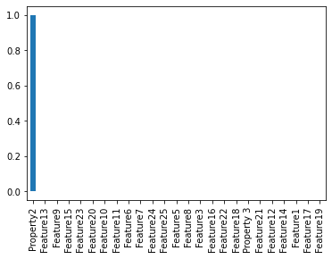

```
Features Selected by RIDGE: ['Property2' 'Feature13' 'Feature9' 'Feature15' 'Feature23' 'Feature20'
 'Feature10' 'Feature11' 'Feature6' 'Feature7' 'Feature24' 'Feature25'
 'Feature5' 'Feature8' 'Feature3' 'Feature16' 'Feature22' 'Feature18'
 'Property 3' 'Feature21' 'Feature12' 'Feature14' 'Feature1' 'Feature17'
 'Feature19']
Important Features by RIDGE: ['Property2']
Optimal alpha for LASSO : 2.5693248891779397
```

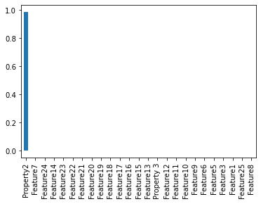

```
Features Selected by LASSO: ['Property2' 'Feature7' 'Feature24' 'Feature8']
Important Features by LASSO: ['Property2']




Target Name: Property2
Feature Selected by Corr: ['Property2', 'Feature7', 'Feature8', 'Feature10', 'Feature11']
Features Selected by Chi: ['Feature6' 'Feature23' 'Feature5' 'Feature25' 'Feature1']
```

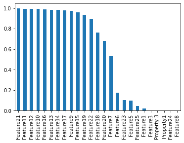

```
Optimal alpha for RIDGE : 0.1
```

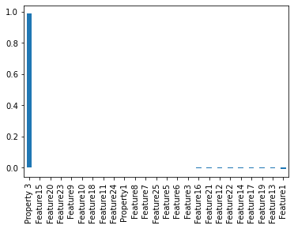

```
Features Selected by RIDGE: ['Property 3' 'Feature15' 'Feature20' 'Feature23' 'Feature9' 'Feature10'
 'Feature18' 'Feature11' 'Feature24' 'Property1' 'Feature8' 'Feature7'
 'Feature25' 'Feature5' 'Feature6' 'Feature3' 'Feature16' 'Feature21'
 'Feature12' 'Feature22' 'Feature14' 'Feature17' 'Feature19' 'Feature13'
 'Feature1']
Important Features by RIDGE: ['Property 3', 'Feature1', 'Feature13', 'Feature15', 'Feature17']
Optimal alpha for LASSO : 0.028160770031217478
```

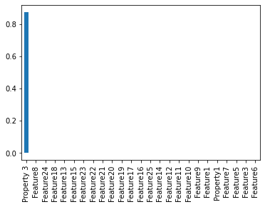

```
Features Selected by LASSO: ['Property 3' 'Feature8' 'Feature24' 'Feature18' 'Property1' 'Feature7'
 'Feature5' 'Feature3' 'Feature6']
Important Features by LASSO: ['Property 3']




Target Name: Property 3
Feature Selected by Corr: ['Feature1']
Features Selected by Chi: ['Feature22' 'Property2' 'Feature23' 'Feature3' 'Feature24']
```

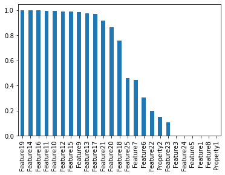

```
Optimal alpha for RIDGE : 0.1
```

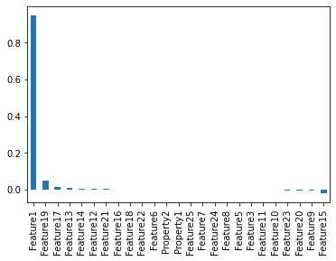

```
Features Selected by RIDGE: ['Feature1' 'Feature19' 'Feature17' 'Feature13' 'Feature14' 'Feature12'
 'Feature21' 'Feature16' 'Feature18' 'Feature22' 'Feature6' 'Property2'
 'Property1' 'Feature25' 'Feature7' 'Feature24' 'Feature8' 'Feature5'
 'Feature3' 'Feature11' 'Feature10' 'Feature23' 'Feature20' 'Feature9'
 'Feature15']
Important Features by RIDGE: ['Feature1', 'Feature9', 'Feature10', 'Feature11', 'Feature12']
Optimal alpha for LASSO : 0.01653459937565036
```

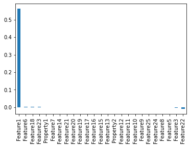

```
Features Selected by LASSO: ['Feature1' 'Feature6' 'Feature18' 'Feature23' 'Property1' 'Feature7'
 'Feature24' 'Feature8' 'Feature5' 'Feature3' 'Feature22']
Important Features by LASSO: ['Feature1', 'Feature3', 'Feature6', 'Feature18', 'Feature22']
```

```python
#Importing the necessary libraries
import pandas as pd
import numpy as np
import matplotlib.pyplot as plt
import seaborn as sns
from sklearn.feature_selection import chi2
from sklearn.linear_model import Lasso
from sklearn.linear_model import Ridge
from sklearn.linear_model import LassoCV
from sklearn.linear_model import RidgeCV

idx = 0
targetsFS = {}

for k,v in targets.items():

    print('\n')
    print(f"Target Name: {k}")
    X, y = v
    #Calculate the correlation between the features
    corr_matrix =df.corr()
    #Correlation with output variable
    cor_target = abs(corr_matrix[k])
    #Selecting highly correlated features
    sorted(abs(num) for num in cor_target)[:5]
    relevant_features = cor_target[abs(cor_target)>0.2]
    try:
        corrFS = list(relevant_features.index)[1:].remove(k)[:5]
    except:
        corrFS = list(relevant_features.index)[1:][:5]

    print(f"Feature Selected by Corr: {corrFS}")

    #Chi-square test
    #apply chi2 test
    try:
        chi_score = chi2(X,y)
        #print the features selected and their performance
        p_values = pd.Series(chi_score[1], index=X.columns)
        p_values.sort_values(ascending = False , inplace = True)
        chiFS = p_values[p_values<0.2].index.values[:5]
        print('Features Selected by Chi:',chiFS)
        p_values.plot.bar()
        plt.show()
    except:
        chiFS = list(X.columns)[:5]
        print("Features Selected by Chi: The chi-squared test takes categorical label data as input.")


    #apply ridge
    regR = RidgeCV(cv=5).fit(X, y)
    #print the optimal alpha for ridge
    print('Optimal alpha for RIDGE :',regR.alpha_)

    #RIDGE
    #initialize Ridge Regression
    ridge = Ridge(alpha=regR.alpha_)
    #fit data
    ridge.fit(X,y)

    #print the features selected and their performance
    p_valuesR = pd.Series(ridge.coef_, index=X.columns)
    p_valuesR.sort_values(ascending = False , inplace = True)
    p_valuesR.plot.bar()
    plt.show()
    ridgeFS = p_valuesR[p_valuesR!=0].index.values
    print('Features Selected by RIDGE:',ridgeFS)

    #extract coefficients
    coefR = ridge.coef_
    feature_namesR = list(df.columns)
    feature_namesR.pop(idx)

    #select important features
    ridgeFS = [feature_namesR[i] for i in range(len(coefR)) if abs(coefR[i]) > 0.001][:5]
    print('Important Features by RIDGE:',ridgeFS)

    #apply LASSO
    regL = LassoCV(cv=5, random_state=0).fit(X, y)
    #print the optimal alpha for LASSO
    print('Optimal alpha for LASSO :',regL.alpha_)

    #LASSO
    reg = Lasso(alpha=regL.alpha_)
    #apply LASSO
    reg.fit(X,y)

    #print the features selected and their performance
    p_values = pd.Series(reg.coef_, index=X.columns)
    p_values.sort_values(ascending = False , inplace = True)
    p_values.plot.bar()
    plt.show()
    lassFS = p_values[p_values!=0].index.values
    print('Features Selected by LASSO:',lassFS)

    #extract coefficients
    coefL = reg.coef_
    feature_namesL = list(df.columns)
    feature_namesL.pop(idx)

    #select important features
    lassFS = [feature_namesL[i] for i in range(len(coefL)) if abs(coefL[i]) > 0.001][:5]
    print('Important Features by LASSO:',lassFS)


    targetsFS[k] = [(chiFS, "CHI"), (corrFS,"CORR"), (lassFS,"LASS"), (ridgeFS,"RIDG")]

    idx+=1
    print('\n')
```

#### For Feature Validation:

We now will validate the feature selection that was done previously for a selection of 3 different data frames. We split the data into a training and test set, and applies standard scaler to both the training and the test sets. Then, the Linear Regression model is fitted to the training data, the model is then used to predict the values for the test set, and the root mean squared error is calculated for each of the feature sets to evaluate the accuracy of the model. The root mean squared error (RMSE) measures how closely the predicted values from a model match the actual values. It is calculated as the square root of the mean of the squared differences between the predicted values and the actual values. In this case, the RMSE value is used to evaluate the accuracy of the Linear Regression model trained on the training set.

```python
import numpy as np
import pandas as pd
import matplotlib.pyplot as plt
from sklearn.metrics import r2_score
from sklearn.model_selection import train_test_split
from sklearn.preprocessing import StandardScaler
from sklearn.linear_model import LinearRegression
from sklearn.metrics import mean_squared_error

summary = []
models = {}

for k, v in  targets.items():

    print(f"Target Name: {k}")
    fittingSet = []

    for fs,name in targetsFS[k]:
        print(f"After Feature Selection by {name}: {fs}")
        fs = list(fs)
        try:
            fs.remove(k)
        except:
            print("Property itself is filtered out.")
        X = df.filter(items=fs)
        display(X)
        # split df into trianing and testing set
        X_train, X_test, y_train, y_test = train_test_split(X, y, test_size = 0.20, random_state = 0)

        # Feature Scaling
        sc_X = StandardScaler()
        X_train = sc_X.fit_transform(X_train)
        X_test = sc_X.transform(X_test)

        # Fitting  Linear Regression to the Training set
        regressor = LinearRegression()
        regressor.fit(X_train, y_train)

        # predicting the Test set results
        y_pred = regressor.predict(X_test)
        fittingSet.append((name,[X_train, X_test, y_train, y_test]))

        # calculate Root Mean Squared Error
        try:
            rmse = np.sqrt(mean_squared_error(y_test, y_pred))
            print(f"Root Mean Squared Error of {name} of {k}: {rmse}")
            summary.append(f"Root Mean Squared Error of {name} of {k}: {rmse}")
        except:
            print(f"Error calculating RMSE of {name} of {k}")

    models[k] = fittingSet
```

```
Target Name: Property1
After Feature Selection by CHI: ['Property2', 'Property 3', 'Feature1', 'Feature3', 'Feature5']
Property itself is filtered out.
```

|  | Property2 | Property 3 | Feature1 | Feature3 | Feature5 |
| --- | --- | --- | --- | --- | --- |
| 12 | 57.2 | 0.0 | 0.0 | 2.5000 | 1373.0 |
| 13 | 66.5 | 1.0 | 0.0 | 0.0000 | 1373.0 |
| 14 | 36.0 | 0.0 | 0.0 | 15.0000 | 1373.0 |
| 15 | 60.2 | 1.0 | 0.0 | 5.0000 | 1373.0 |
| 16 | 40.0 | 1.0 | 0.0 | 5.0000 | 1473.0 |
| ... | ... | ... | ... | ... | ... |
| 73 | 43.0 | 1.0 | 0.0 | 33.3333 | 1373.0 |
| 74 | 51.0 | 1.0 | 0.0 | 33.3333 | 1373.0 |
| 75 | 64.0 | 0.0 | 0.0 | 33.3333 | 1373.0 |
| 76 | 68.0 | 0.0 | 0.0 | 33.3333 | 1373.0 |
| 77 | 68.0 | 0.0 | 0.0 | 33.3333 | 1373.0 |

62 rows × 5 columns

```
Root Mean Squared Error of CHI of Property1: 2.181914451592451e-16
After Feature Selection by CORR: ['Property2', 'Feature1', 'Feature7', 'Feature10', 'Feature11']
Property itself is filtered out.
```

|  | Property2 | Feature1 | Feature7 | Feature10 | Feature11 |
| --- | --- | --- | --- | --- | --- |
| 12 | 57.2 | 0.0 | 1273.0 | 1.262 | 1.173 |
| 13 | 66.5 | 0.0 | 1273.0 | 1.262 | 1.173 |
| 14 | 36.0 | 0.0 | 1173.0 | 1.262 | 1.173 |
| 15 | 60.2 | 0.0 | 1223.0 | 1.262 | 1.173 |
| 16 | 40.0 | 0.0 | 1123.0 | 1.262 | 1.173 |
| ... | ... | ... | ... | ... | ... |
| 73 | 43.0 | 0.0 | 923.0 | 1.267 | 1.171 |
| 74 | 51.0 | 0.0 | 973.0 | 1.267 | 1.171 |
| 75 | 64.0 | 0.0 | 1073.0 | 1.267 | 1.171 |
| 76 | 68.0 | 0.0 | 1173.0 | 1.267 | 1.171 |
| 77 | 68.0 | 0.0 | 1373.0 | 1.267 | 1.171 |

62 rows × 5 columns

```
Root Mean Squared Error of CORR of Property1: 5.276227497353691e-16
After Feature Selection by LASS: ['Property2']
Property itself is filtered out.
```

|  | Property2 |
| --- | --- |
| 12 | 57.2 |
| 13 | 66.5 |
| 14 | 36.0 |
| 15 | 60.2 |
| 16 | 40.0 |
| ... | ... |
| 73 | 43.0 |
| 74 | 51.0 |
| 75 | 64.0 |
| 76 | 68.0 |
| 77 | 68.0 |

62 rows × 1 columns

```
Root Mean Squared Error of LASS of Property1: 0.37184181351942314
After Feature Selection by RIDG: ['Property2']
Property itself is filtered out.
```

|  | Property2 |
| --- | --- |
| 12 | 57.2 |
| 13 | 66.5 |
| 14 | 36.0 |
| 15 | 60.2 |
| 16 | 40.0 |
| ... | ... |
| 73 | 43.0 |
| 74 | 51.0 |
| 75 | 64.0 |
| 76 | 68.0 |
| 77 | 68.0 |

62 rows × 1 columns

```
Root Mean Squared Error of RIDG of Property1: 0.37184181351942314
Target Name: Property2
After Feature Selection by CHI: ['Feature6' 'Feature23' 'Feature5' 'Feature25' 'Feature1']
Property itself is filtered out.
```

|  | Feature6 | Feature23 | Feature5 | Feature25 | Feature1 |
| --- | --- | --- | --- | --- | --- |
| 12 | 75.0 | 45.923 | 1373.0 | 48.0 | 0.0 |
| 13 | 75.0 | 45.923 | 1373.0 | 43.9 | 0.0 |
| 14 | 75.0 | 45.923 | 1373.0 | 57.0 | 0.0 |
| 15 | 75.0 | 45.923 | 1373.0 | 60.0 | 0.0 |
| 16 | 50.0 | 45.923 | 1473.0 | 52.8 | 0.0 |
| ... | ... | ... | ... | ... | ... |
| 73 | 78.0 | 8.510 | 1373.0 | 40.0 | 0.0 |
| 74 | 78.0 | 8.510 | 1373.0 | 56.5 | 0.0 |
| 75 | 78.0 | 8.510 | 1373.0 | 60.2 | 0.0 |
| 76 | 78.0 | 8.510 | 1373.0 | 10.9 | 0.0 |
| 77 | 78.0 | 8.510 | 1373.0 | 7.6 | 0.0 |

62 rows × 5 columns

```
Root Mean Squared Error of CHI of Property2: 2.5327511127985122e-16
After Feature Selection by CORR: ['Property2', 'Feature7', 'Feature8', 'Feature10', 'Feature11']
```

|  | Feature7 | Feature8 | Feature10 | Feature11 |
| --- | --- | --- | --- | --- |
| 12 | 1273.0 | 990.0 | 1.262 | 1.173 |
| 13 | 1273.0 | 950.0 | 1.262 | 1.173 |
| 14 | 1173.0 | 645.0 | 1.262 | 1.173 |
| 15 | 1223.0 | 360.0 | 1.262 | 1.173 |
| 16 | 1123.0 | 125.0 | 1.262 | 1.173 |
| ... | ... | ... | ... | ... |
| 73 | 923.0 | 345.0 | 1.267 | 1.171 |
| 74 | 973.0 | 195.0 | 1.267 | 1.171 |
| 75 | 1073.0 | 105.0 | 1.267 | 1.171 |
| 76 | 1173.0 | 80.0 | 1.267 | 1.171 |
| 77 | 1373.0 | 50.0 | 1.267 | 1.171 |

62 rows × 4 columns

```
Root Mean Squared Error of CORR of Property2: 0.3797328416794795
After Feature Selection by LASS: ['Property 3']
Property itself is filtered out.
```

|  | Property 3 |
| --- | --- |
| 12 | 0.0 |
| 13 | 1.0 |
| 14 | 0.0 |
| 15 | 1.0 |
| 16 | 1.0 |
| ... | ... |
| 73 | 1.0 |
| 74 | 1.0 |
| 75 | 0.0 |
| 76 | 0.0 |
| 77 | 0.0 |

62 rows × 1 columns

```
Root Mean Squared Error of LASS of Property2: 0.3499450506315791
After Feature Selection by RIDG: ['Property 3', 'Feature1', 'Feature13', 'Feature15', 'Feature17']
Property itself is filtered out.
```

|  | Property 3 | Feature1 | Feature13 | Feature15 | Feature17 |
| --- | --- | --- | --- | --- | --- |
| 12 | 0.0 | 0.0 | 14.240 | 7.364 | 0.847 |
| 13 | 1.0 | 0.0 | 14.240 | 7.364 | 0.847 |
| 14 | 0.0 | 0.0 | 14.240 | 7.364 | 0.847 |
| 15 | 1.0 | 0.0 | 14.240 | 7.364 | 0.847 |
| 16 | 1.0 | 0.0 | 14.240 | 7.364 | 0.847 |
| ... | ... | ... | ... | ... | ... |
| 73 | 1.0 | 0.0 | 14.523 | 7.488 | 1.034 |
| 74 | 1.0 | 0.0 | 14.523 | 7.488 | 1.034 |
| 75 | 0.0 | 0.0 | 14.523 | 7.488 | 1.034 |
| 76 | 0.0 | 0.0 | 14.523 | 7.488 | 1.034 |
| 77 | 0.0 | 0.0 | 14.523 | 7.488 | 1.034 |

62 rows × 5 columns

```
Root Mean Squared Error of RIDG of Property2: 1.8588147821822732e-16
Target Name: Property 3
After Feature Selection by CHI: ['Feature22' 'Property2' 'Feature23' 'Feature3' 'Feature24']
Property itself is filtered out.
```

|  | Feature22 | Property2 | Feature23 | Feature3 | Feature24 |
| --- | --- | --- | --- | --- | --- |
| 12 | 202.410 | 57.2 | 45.923 | 2.5000 | 401.0 |
| 13 | 202.410 | 66.5 | 45.923 | 0.0000 | 740.0 |
| 14 | 202.410 | 36.0 | 45.923 | 15.0000 | 390.0 |
| 15 | 202.410 | 60.2 | 45.923 | 5.0000 | 530.0 |
| 16 | 202.410 | 40.0 | 45.923 | 5.0000 | 615.8 |
| ... | ... | ... | ... | ... | ... |
| 73 | 197.593 | 43.0 | 8.510 | 33.3333 | 146.0 |
| 74 | 197.593 | 51.0 | 8.510 | 33.3333 | 238.0 |
| 75 | 197.593 | 64.0 | 8.510 | 33.3333 | 530.0 |
| 76 | 197.593 | 68.0 | 8.510 | 33.3333 | 342.0 |
| 77 | 197.593 | 68.0 | 8.510 | 33.3333 | 634.0 |

62 rows × 5 columns

```
Root Mean Squared Error of CHI of Property 3: 0.35221429683972677
After Feature Selection by CORR: ['Feature1']
Property itself is filtered out.
```

|  | Feature1 |
| --- | --- |
| 12 | 0.0 |
| 13 | 0.0 |
| 14 | 0.0 |
| 15 | 0.0 |
| 16 | 0.0 |
| ... | ... |
| 73 | 0.0 |
| 74 | 0.0 |
| 75 | 0.0 |
| 76 | 0.0 |
| 77 | 0.0 |

62 rows × 1 columns

```
Root Mean Squared Error of CORR of Property 3: 1.7523547437286168e-16
After Feature Selection by LASS: ['Feature1', 'Feature3', 'Feature6', 'Feature18', 'Feature22']
Property itself is filtered out.
```

|  | Feature1 | Feature3 | Feature6 | Feature18 | Feature22 |
| --- | --- | --- | --- | --- | --- |
| 12 | 0.0 | 2.5000 | 75.0 | 1705.102 | 202.410 |
| 13 | 0.0 | 0.0000 | 75.0 | 1705.102 | 202.410 |
| 14 | 0.0 | 15.0000 | 75.0 | 1705.102 | 202.410 |
| 15 | 0.0 | 5.0000 | 75.0 | 1705.102 | 202.410 |
| 16 | 0.0 | 5.0000 | 50.0 | 1705.102 | 202.410 |
| ... | ... | ... | ... | ... | ... |
| 73 | 0.0 | 33.3333 | 78.0 | 1713.260 | 197.593 |
| 74 | 0.0 | 33.3333 | 78.0 | 1713.260 | 197.593 |
| 75 | 0.0 | 33.3333 | 78.0 | 1713.260 | 197.593 |
| 76 | 0.0 | 33.3333 | 78.0 | 1713.260 | 197.593 |
| 77 | 0.0 | 33.3333 | 78.0 | 1713.260 | 197.593 |

62 rows × 5 columns

```
Root Mean Squared Error of LASS of Property 3: 1.1211778002867444e-16
After Feature Selection by RIDG: ['Feature1', 'Feature9', 'Feature10', 'Feature11', 'Feature12']
Property itself is filtered out.
```

|  | Feature1 | Feature9 | Feature10 | Feature11 | Feature12 |
| --- | --- | --- | --- | --- | --- |
| 12 | 0.0 | 2.160 | 1.262 | 1.173 | 0.496 |
| 13 | 0.0 | 2.160 | 1.262 | 1.173 | 0.496 |
| 14 | 0.0 | 2.160 | 1.262 | 1.173 | 0.496 |
| 15 | 0.0 | 2.160 | 1.262 | 1.173 | 0.496 |
| 16 | 0.0 | 2.160 | 1.262 | 1.173 | 0.496 |
| ... | ... | ... | ... | ... | ... |
| 73 | 0.0 | 2.104 | 1.267 | 1.171 | 0.499 |
| 74 | 0.0 | 2.104 | 1.267 | 1.171 | 0.499 |
| 75 | 0.0 | 2.104 | 1.267 | 1.171 | 0.499 |
| 76 | 0.0 | 2.104 | 1.267 | 1.171 | 0.499 |
| 77 | 0.0 | 2.104 | 1.267 | 1.171 | 0.499 |

62 rows × 5 columns

```
Root Mean Squared Error of RIDG of Property 3: 1.1778838237471097e-16
```

#### Root Mean Squared Error of Feature Selection Methods

```python
summary
```

```
['Root Mean Squared Error of CHI of Property1: 2.181914451592451e-16',
 'Root Mean Squared Error of CORR of Property1: 5.276227497353691e-16',
 'Root Mean Squared Error of LASS of Property1: 0.37184181351942314',
 'Root Mean Squared Error of RIDG of Property1: 0.37184181351942314',
 'Root Mean Squared Error of CHI of Property2: 2.5327511127985122e-16',
 'Root Mean Squared Error of CORR of Property2: 0.3797328416794795',
 'Root Mean Squared Error of LASS of Property2: 0.3499450506315791',
 'Root Mean Squared Error of RIDG of Property2: 1.8588147821822732e-16',
 'Root Mean Squared Error of CHI of Property 3: 0.35221429683972677',
 'Root Mean Squared Error of CORR of Property 3: 1.7523547437286168e-16',
 'Root Mean Squared Error of LASS of Property 3: 1.1211778002867444e-16',
 'Root Mean Squared Error of RIDG of Property 3: 1.1778838237471097e-16']
```

#### For Feature Selection Methods:

```
Modeling for Property1.
Fit model and display performance metrics for features selected by CHI for Property1.
```

```
MLP accuracy score: 1.0
SVM accuracy score: 1.0
GNB accuracy score: 1.0
KNN accuracy score: 1.0
Decision Tree accuracy score: 1.0
Random Forest accuracy score: 0.9230769230769231
Logistic Regression accuracy score: 1.0
MLP precision score: 1.0
SVM precision score: 1.0
GNB precision score: 1.0
KNN precision score: 1.0
Decision Tree precision score: 1.0
Random Forest precision score: 1.0
Logistic Regression precision score: 1.0
MLP recall score: 1.0
SVM recall score: 1.0
GNB recall score: 1.0
KNN recall score: 1.0
Decision Tree recall score: 1.0
Random Forest recall score: 0.5
Logistic Regression recall score: 1.0
MLP f1 score: 1.0
SVM f1 score: 1.0
GNB f1 score: 1.0
KNN f1 score: 1.0
Decision Tree f1 score: 1.0
Random Forest f1 score: 0.6666666666666666
Logistic Regression f1 score: 1.0
MLP AUC: 1.000
SVM AUC: 1.000
GNB AUC: 1.000
KNN AUC: 1.000
Tree AUC: 1.000
Forest AUC: 0.750
Log AUC: 1.000
```

```
Fit model and display performance metrics for features selected by CORR for Property1.
```

```
MLP accuracy score: 1.0
SVM accuracy score: 1.0
GNB accuracy score: 1.0
KNN accuracy score: 1.0
Decision Tree accuracy score: 1.0
Random Forest accuracy score: 1.0
Logistic Regression accuracy score: 1.0
MLP precision score: 1.0
SVM precision score: 1.0
GNB precision score: 1.0
KNN precision score: 1.0
Decision Tree precision score: 1.0
Random Forest precision score: 1.0
Logistic Regression precision score: 1.0
MLP recall score: 1.0
SVM recall score: 1.0
GNB recall score: 1.0
KNN recall score: 1.0
Decision Tree recall score: 1.0
Random Forest recall score: 1.0
Logistic Regression recall score: 1.0
MLP f1 score: 1.0
SVM f1 score: 1.0
GNB f1 score: 1.0
KNN f1 score: 1.0
Decision Tree f1 score: 1.0
Random Forest f1 score: 1.0
Logistic Regression f1 score: 1.0
MLP AUC: 1.000
SVM AUC: 1.000
GNB AUC: 1.000
KNN AUC: 1.000
Tree AUC: 1.000
Forest AUC: 1.000
Log AUC: 1.000
```

```
Fit model and display performance metrics for features selected by LASS for Property1.
MLP accuracy score: 0.8461538461538461
SVM accuracy score: 0.8461538461538461
GNB accuracy score: 0.8461538461538461
KNN accuracy score: 0.8461538461538461
Decision Tree accuracy score: 0.8461538461538461
Random Forest accuracy score: 0.8461538461538461
Logistic Regression accuracy score: 0.8461538461538461
MLP precision score: 0.0
SVM precision score: 0.0
GNB precision score: 0.0
KNN precision score: 0.0
Decision Tree precision score: 0.0
Random Forest precision score: 0.0
Logistic Regression precision score: 0.0
MLP recall score: 0.0
SVM recall score: 0.0
GNB recall score: 0.0
KNN recall score: 0.0
Decision Tree recall score: 0.0
Random Forest recall score: 0.0
Logistic Regression recall score: 0.0
MLP f1 score: 0.0
SVM f1 score: 0.0
GNB f1 score: 0.0
KNN f1 score: 0.0
Decision Tree f1 score: 0.0
Random Forest f1 score: 0.0
Logistic Regression f1 score: 0.0
MLP AUC: 0.500
SVM AUC: 0.500
GNB AUC: 0.500
KNN AUC: 0.500
Tree AUC: 0.500
Forest AUC: 0.500
Log AUC: 0.500
```

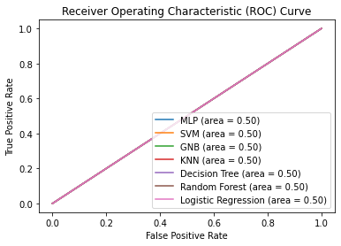

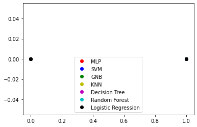

```
Fit model and display performance metrics for features selected by RIDG for Property1.
MLP accuracy score: 0.8461538461538461
SVM accuracy score: 0.8461538461538461
GNB accuracy score: 0.8461538461538461
KNN accuracy score: 0.8461538461538461
Decision Tree accuracy score: 0.8461538461538461
Random Forest accuracy score: 0.8461538461538461
Logistic Regression accuracy score: 0.8461538461538461
MLP precision score: 0.0
SVM precision score: 0.0
GNB precision score: 0.0
KNN precision score: 0.0
Decision Tree precision score: 0.0
Random Forest precision score: 0.0
Logistic Regression precision score: 0.0
MLP recall score: 0.0
SVM recall score: 0.0
GNB recall score: 0.0
KNN recall score: 0.0
Decision Tree recall score: 0.0
Random Forest recall score: 0.0
Logistic Regression recall score: 0.0
MLP f1 score: 0.0
SVM f1 score: 0.0
GNB f1 score: 0.0
KNN f1 score: 0.0
Decision Tree f1 score: 0.0
Random Forest f1 score: 0.0
Logistic Regression f1 score: 0.0
MLP AUC: 0.500
SVM AUC: 0.500
GNB AUC: 0.500
KNN AUC: 0.500
Tree AUC: 0.500
Forest AUC: 0.500
Log AUC: 0.500
```

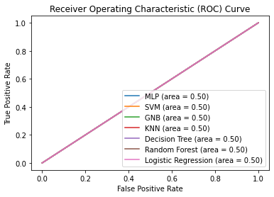

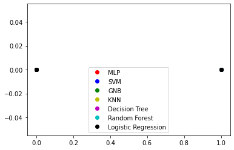

```
Modeling for Property2.
Fit model and display performance metrics for features selected by CHI for Property2.
MLP accuracy score: 1.0
SVM accuracy score: 1.0
GNB accuracy score: 1.0
KNN accuracy score: 1.0
Decision Tree accuracy score: 1.0
Random Forest accuracy score: 0.9230769230769231
Logistic Regression accuracy score: 1.0
MLP precision score: 1.0
SVM precision score: 1.0
GNB precision score: 1.0
KNN precision score: 1.0
Decision Tree precision score: 1.0
Random Forest precision score: 1.0
Logistic Regression precision score: 1.0
MLP recall score: 1.0
SVM recall score: 1.0
GNB recall score: 1.0
KNN recall score: 1.0
Decision Tree recall score: 1.0
Random Forest recall score: 0.5
Logistic Regression recall score: 1.0
MLP f1 score: 1.0
SVM f1 score: 1.0
GNB f1 score: 1.0
KNN f1 score: 1.0
Decision Tree f1 score: 1.0
Random Forest f1 score: 0.6666666666666666
Logistic Regression f1 score: 1.0
MLP AUC: 1.000
SVM AUC: 1.000
GNB AUC: 1.000
KNN AUC: 1.000
Tree AUC: 1.000
Forest AUC: 0.750
Log AUC: 1.000
```

```
Fit model and display performance metrics for features selected by CORR for Property2.
MLP accuracy score: 0.8461538461538461
SVM accuracy score: 0.8461538461538461
GNB accuracy score: 0.8461538461538461
KNN accuracy score: 0.8461538461538461
Decision Tree accuracy score: 0.9230769230769231
Random Forest accuracy score: 0.9230769230769231
Logistic Regression accuracy score: 0.8461538461538461
MLP precision score: 0.0
SVM precision score: 0.0
GNB precision score: 0.5
KNN precision score: 0.0
Decision Tree precision score: 1.0
Random Forest precision score: 1.0
Logistic Regression precision score: 0.0
MLP recall score: 0.0
SVM recall score: 0.0
GNB recall score: 0.5
KNN recall score: 0.0
Decision Tree recall score: 0.5
Random Forest recall score: 0.5
Logistic Regression recall score: 0.0
MLP f1 score: 0.0
SVM f1 score: 0.0
GNB f1 score: 0.5
KNN f1 score: 0.0
Decision Tree f1 score: 0.6666666666666666
Random Forest f1 score: 0.6666666666666666
Logistic Regression f1 score: 0.0
MLP AUC: 0.500
SVM AUC: 0.500
GNB AUC: 0.705
KNN AUC: 0.500
Tree AUC: 0.750
Forest AUC: 0.750
Log AUC: 0.500
```

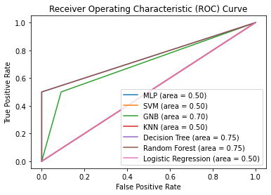

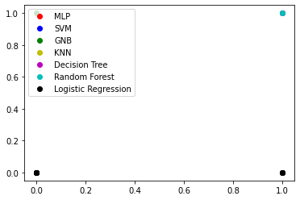

```
Fit model and display performance metrics for features selected by LASS for Property2.
MLP accuracy score: 0.8461538461538461
SVM accuracy score: 0.8461538461538461
GNB accuracy score: 0.7692307692307693
KNN accuracy score: 0.8461538461538461
Decision Tree accuracy score: 0.8461538461538461
Random Forest accuracy score: 0.8461538461538461
Logistic Regression accuracy score: 0.8461538461538461
MLP precision score: 0.0
SVM precision score: 0.0
GNB precision score: 0.4
KNN precision score: 0.0
Decision Tree precision score: 0.0
Random Forest precision score: 0.0
Logistic Regression precision score: 0.0
MLP recall score: 0.0
SVM recall score: 0.0
GNB recall score: 1.0
KNN recall score: 0.0
Decision Tree recall score: 0.0
Random Forest recall score: 0.0
Logistic Regression recall score: 0.0
MLP f1 score: 0.0
SVM f1 score: 0.0
GNB f1 score: 0.5714285714285715
KNN f1 score: 0.0
Decision Tree f1 score: 0.0
Random Forest f1 score: 0.0
Logistic Regression f1 score: 0.0
MLP AUC: 0.500
SVM AUC: 0.500
GNB AUC: 0.864
KNN AUC: 0.500
Tree AUC: 0.500
Forest AUC: 0.500
Log AUC: 0.500
```

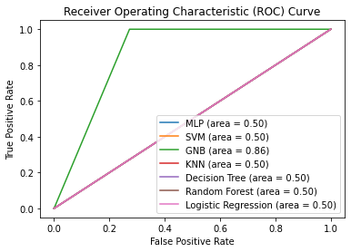

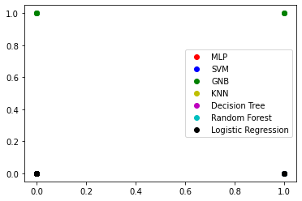

```
Fit model and display performance metrics for features selected by RIDG for Property2.
MLP accuracy score: 1.0
SVM accuracy score: 1.0
GNB accuracy score: 1.0
KNN accuracy score: 1.0
Decision Tree accuracy score: 1.0
Random Forest accuracy score: 0.9230769230769231
Logistic Regression accuracy score: 1.0
MLP precision score: 1.0
SVM precision score: 1.0
GNB precision score: 1.0
KNN precision score: 1.0
Decision Tree precision score: 1.0
Random Forest precision score: 1.0
Logistic Regression precision score: 1.0
MLP recall score: 1.0
SVM recall score: 1.0
GNB recall score: 1.0
KNN recall score: 1.0
Decision Tree recall score: 1.0
Random Forest recall score: 0.5
Logistic Regression recall score: 1.0
MLP f1 score: 1.0
SVM f1 score: 1.0
GNB f1 score: 1.0
KNN f1 score: 1.0
Decision Tree f1 score: 1.0
Random Forest f1 score: 0.6666666666666666
Logistic Regression f1 score: 1.0
MLP AUC: 1.000
SVM AUC: 1.000
GNB AUC: 1.000
KNN AUC: 1.000
Tree AUC: 1.000
Forest AUC: 0.750
Log AUC: 1.000
```

```
Modeling for Property 3.
Fit model and display performance metrics for features selected by CHI for Property 3.
MLP accuracy score: 0.8461538461538461
SVM accuracy score: 0.8461538461538461
GNB accuracy score: 0.9230769230769231
KNN accuracy score: 0.8461538461538461
Decision Tree accuracy score: 0.9230769230769231
Random Forest accuracy score: 0.9230769230769231
Logistic Regression accuracy score: 0.8461538461538461
MLP precision score: 0.0
SVM precision score: 0.0
GNB precision score: 1.0
KNN precision score: 0.0
Decision Tree precision score: 1.0
Random Forest precision score: 1.0
Logistic Regression precision score: 0.0
MLP recall score: 0.0
SVM recall score: 0.0
GNB recall score: 0.5
KNN recall score: 0.0
Decision Tree recall score: 0.5
Random Forest recall score: 0.5
Logistic Regression recall score: 0.0
MLP f1 score: 0.0
SVM f1 score: 0.0
GNB f1 score: 0.6666666666666666
KNN f1 score: 0.0
Decision Tree f1 score: 0.6666666666666666
Random Forest f1 score: 0.6666666666666666
Logistic Regression f1 score: 0.0
MLP AUC: 0.500
SVM AUC: 0.500
GNB AUC: 0.750
KNN AUC: 0.500
Tree AUC: 0.750
Forest AUC: 0.750
Log AUC: 0.500
```

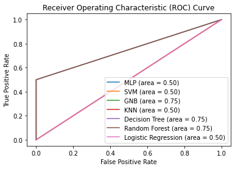

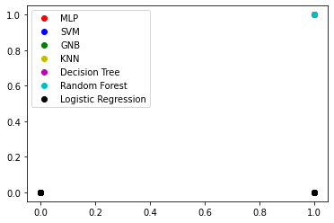

```
Fit model and display performance metrics for features selected by CORR for Property 3.
MLP accuracy score: 1.0
SVM accuracy score: 1.0
GNB accuracy score: 1.0
KNN accuracy score: 1.0
Decision Tree accuracy score: 1.0
Random Forest accuracy score: 1.0
Logistic Regression accuracy score: 1.0
MLP precision score: 1.0
SVM precision score: 1.0
GNB precision score: 1.0
KNN precision score: 1.0
Decision Tree precision score: 1.0
Random Forest precision score: 1.0
Logistic Regression precision score: 1.0
MLP recall score: 1.0
SVM recall score: 1.0
GNB recall score: 1.0
KNN recall score: 1.0
Decision Tree recall score: 1.0
Random Forest recall score: 1.0
Logistic Regression recall score: 1.0
MLP f1 score: 1.0
SVM f1 score: 1.0
GNB f1 score: 1.0
KNN f1 score: 1.0
Decision Tree f1 score: 1.0
Random Forest f1 score: 1.0
Logistic Regression f1 score: 1.0
MLP AUC: 1.000
SVM AUC: 1.000
GNB AUC: 1.000
KNN AUC: 1.000
Tree AUC: 1.000
Forest AUC: 1.000
Log AUC: 1.000
```

```
Fit model and display performance metrics for features selected by LASS for Property 3.
MLP accuracy score: 1.0
SVM accuracy score: 1.0
GNB accuracy score: 1.0
KNN accuracy score: 1.0
Decision Tree accuracy score: 1.0
Random Forest accuracy score: 1.0
Logistic Regression accuracy score: 1.0
MLP precision score: 1.0
SVM precision score: 1.0
GNB precision score: 1.0
KNN precision score: 1.0
Decision Tree precision score: 1.0
Random Forest precision score: 1.0
Logistic Regression precision score: 1.0
MLP recall score: 1.0
SVM recall score: 1.0
GNB recall score: 1.0
KNN recall score: 1.0
Decision Tree recall score: 1.0
Random Forest recall score: 1.0
Logistic Regression recall score: 1.0
MLP f1 score: 1.0
SVM f1 score: 1.0
GNB f1 score: 1.0
KNN f1 score: 1.0
Decision Tree f1 score: 1.0
Random Forest f1 score: 1.0
Logistic Regression f1 score: 1.0
MLP AUC: 1.000
SVM AUC: 1.000
GNB AUC: 1.000
KNN AUC: 1.000
Tree AUC: 1.000
Forest AUC: 1.000
Log AUC: 1.000
```

```
Fit model and display performance metrics for features selected by RIDG for Property 3.
MLP accuracy score: 1.0
SVM accuracy score: 1.0
GNB accuracy score: 1.0
KNN accuracy score: 1.0
Decision Tree accuracy score: 1.0
Random Forest accuracy score: 1.0
Logistic Regression accuracy score: 1.0
MLP precision score: 1.0
SVM precision score: 1.0
GNB precision score: 1.0
KNN precision score: 1.0
Decision Tree precision score: 1.0
Random Forest precision score: 1.0
Logistic Regression precision score: 1.0
MLP recall score: 1.0
SVM recall score: 1.0
GNB recall score: 1.0
KNN recall score: 1.0
Decision Tree recall score: 1.0
Random Forest recall score: 1.0
Logistic Regression recall score: 1.0
MLP f1 score: 1.0
SVM f1 score: 1.0
GNB f1 score: 1.0
KNN f1 score: 1.0
Decision Tree f1 score: 1.0
Random Forest f1 score: 1.0
Logistic Regression f1 score: 1.0
```

```
MLP AUC: 1.000
SVM AUC: 1.000
GNB AUC: 1.000
KNN AUC: 1.000
Tree AUC: 1.000
Forest AUC: 1.000
Log AUC: 1.000
```

```python
# Import all the necessary libraries
from sklearn.neural_network import MLPClassifier
from sklearn.svm import SVC
from sklearn.naive_bayes import GaussianNB
from sklearn.neighbors import KNeighborsClassifier
from sklearn.tree import DecisionTreeClassifier
from sklearn.ensemble import RandomForestClassifier
from sklearn.linear_model import LogisticRegression
from sklearn.metrics import *
import matplotlib.pyplot as plt

modelObjs = {}

for k,fittingSet in models.items():

    print(f"Modeling for {k}.")

    #iterate over content from fittingSet
    for content in fittingSet:

        #name of feature selection technique and value into variables
        name , i = content[0], content[1]
        print(f"Fit model and display performance metrics for features selected by {name} for {k}.")

        #assign feature selection results to X_train, X_test, y_train, y_test
        X_train, X_test, y_train, y_test = i[0],i[1],i[2],i[3]

        #Instanciate MLPClassifier
        mlp_clf = MLPClassifier()
        #fit MLPClassifier with X_train, y_train
        mlp_clf.fit(X_train, y_train)

        #Instanciate SVC
        svm_clf = SVC()
        #fit SVC with X_train, y_train
        svm_clf.fit(X_train, y_train)

        #Instanciate GaussianNB
        gnb_clf = GaussianNB()
        #fit GaussianNB with X_train, y_train
        gnb_clf.fit(X_train, y_train)

        #Instanciate KNeighborsClassifier
        knn_clf = KNeighborsClassifier()
        #fit KNeighborsClassifier with X_train, y_train
        knn_clf.fit(X_train, y_train)

        #Instanciate DecisionTreeClassifier
        tree_clf = DecisionTreeClassifier()
        #fit DecisionTreeClassifier with X_train, y_train
        tree_clf.fit(X_train, y_train)

        #Instanciate RandomForestClassifier
        forest_clf = RandomForestClassifier()
        #fit RandomForestClassifier with X_train, y_train
        forest_clf.fit(X_train, y_train)

        #Instanciate LogisticRegression
        log_clf = LogisticRegression()
        #fit LogisticRegression with X_train, y_train
        log_clf.fit(X_train, y_train)

        # Predict the response for test dataset
        mlp_pred = mlp_clf.predict(X_test)
        svm_pred = svm_clf.predict(X_test)
        gnb_pred = gnb_clf.predict(X_test)
        knn_pred = knn_clf.predict(X_test)
        tree_pred = tree_clf.predict(X_test)
        forest_pred = forest_clf.predict(X_test)
        log_pred = log_clf.predict(X_test)


        # Add the model objects
        classifiers = {
            'mlp_clf': mlp_clf,
            'svm_clf': svm_clf,
            'gnb_clf': gnb_clf,
            'knn_clf': knn_clf,
            'tree_clf': tree_clf,
            'forest_clf': forest_clf,
            'log_clf': log_clf
        }

        modelObjs[k] = classifiers

        # Model evaluation
        print("MLP accuracy score:", accuracy_score(y_test, mlp_pred))
        print("SVM accuracy score:", accuracy_score(y_test, svm_pred))
        print("GNB accuracy score:", accuracy_score(y_test, gnb_pred))
        print("KNN accuracy score:", accuracy_score(y_test, knn_pred))
        print("Decision Tree accuracy score:", accuracy_score(y_test, tree_pred))
        print("Random Forest accuracy score:", accuracy_score(y_test, forest_pred))
        print("Logistic Regression accuracy score:", accuracy_score(y_test, log_pred))
        print("MLP precision score:", precision_score(y_test, mlp_pred))
        print("SVM precision score:", precision_score(y_test, svm_pred))
        print("GNB precision score:", precision_score(y_test, gnb_pred))
        print("KNN precision score:", precision_score(y_test, knn_pred))
        print("Decision Tree precision score:", precision_score(y_test, tree_pred))
        print("Random Forest precision score:", precision_score(y_test, forest_pred))
        print("Logistic Regression precision score:", precision_score(y_test, log_pred))
        print("MLP recall score:", recall_score(y_test, mlp_pred))
        print("SVM recall score:", recall_score(y_test, svm_pred))
        print("GNB recall score:", recall_score(y_test, gnb_pred))
        print("KNN recall score:", recall_score(y_test, knn_pred))
        print("Decision Tree recall score:", recall_score(y_test, tree_pred))
        print("Random Forest recall score:", recall_score(y_test, forest_pred))
        print("Logistic Regression recall score:", recall_score(y_test, log_pred))
        print("MLP f1 score:", f1_score(y_test, mlp_pred))
        print("SVM f1 score:", f1_score(y_test, svm_pred))
        print("GNB f1 score:", f1_score(y_test, gnb_pred))
        print("KNN f1 score:", f1_score(y_test, knn_pred))
        print("Decision Tree f1 score:", f1_score(y_test, tree_pred))
        print("Random Forest f1 score:", f1_score(y_test, forest_pred))
        print("Logistic Regression f1 score:", f1_score(y_test, log_pred))

        # Calculate the ROC curve
        mlp_fpr, mlp_tpr, mlp_thresholds = roc_curve(y_test, mlp_pred)
        svm_fpr, svm_tpr, svm_thresholds = roc_curve(y_test, svm_pred)
        gnb_fpr, gnb_tpr, gnb_thresholds = roc_curve(y_test, gnb_pred)
        knn_fpr, knn_tpr, knn_thresholds = roc_curve(y_test, knn_pred)
        tree_fpr, tree_tpr, tree_thresholds = roc_curve(y_test, tree_pred)
        forest_fpr, forest_tpr, forest_thresholds = roc_curve(y_test, forest_pred)
        log_fpr, log_tpr, log_thresholds = roc_curve(y_test, log_pred)

        # Calculate the AUC
        mlp_auc = roc_auc_score(y_test, mlp_pred)
        svm_auc = roc_auc_score(y_test, svm_pred)
        gnb_auc = roc_auc_score(y_test, gnb_pred)
        knn_auc = roc_auc_score(y_test, knn_pred)
        tree_auc = roc_auc_score(y_test, tree_pred)
        forest_auc = roc_auc_score(y_test, forest_pred)
        log_auc = roc_auc_score(y_test, log_pred)

        #Print the AUC for each model
        print('MLP AUC: %.3f' % mlp_auc)
        print('SVM AUC: %.3f' % svm_auc)
        print('GNB AUC: %.3f' % gnb_auc)
        print('KNN AUC: %.3f' % knn_auc)
        print('Tree AUC: %.3f' % tree_auc)
        print('Forest AUC: %.3f' % forest_auc)
        print('Log AUC: %.3f' % log_auc)

        # Plot the ROC curves
        plt.plot(mlp_fpr, mlp_tpr, label='MLP (area = %0.2f)' % mlp_auc)
        plt.plot(svm_fpr, svm_tpr, label='SVM (area = %0.2f)' % svm_auc)
        plt.plot(gnb_fpr, gnb_tpr, label='GNB (area = %0.2f)' % gnb_auc)
        plt.plot(knn_fpr, knn_tpr, label='KNN (area = %0.2f)' % knn_auc)
        plt.plot(tree_fpr, tree_tpr, label='Decision Tree (area = %0.2f)' % tree_auc)
        plt.plot(forest_fpr, forest_tpr, label='Random Forest (area = %0.2f)' % forest_auc)
        plt.plot(log_fpr, log_tpr, label='Logistic Regression (area = %0.2f)' % log_auc)

        # Plot attributes
        plt.xlabel('False Positive Rate')
        plt.ylabel('True Positive Rate')
        plt.title('Receiver Operating Characteristic (ROC) Curve')
        plt.legend(loc="lower right")
        plt.show()

        # Plot the predicted data
        plt.plot(y_test, mlp_pred, 'ro', label='MLP')
        plt.plot(y_test, svm_pred, 'bo', label='SVM')
        plt.plot(y_test, gnb_pred, 'go', label='GNB')
        plt.plot(y_test, knn_pred, 'yo', label='KNN')
        plt.plot(y_test, tree_pred, 'mo', label='Decision Tree')
        plt.plot(y_test, forest_pred, 'co', label='Random Forest')
        plt.plot(y_test, log_pred, 'ko', label='Logistic Regression')
        plt.legend()
        plt.show()
```